# Travel Package Purchase Prediction

#### Missing value - Monthly Income

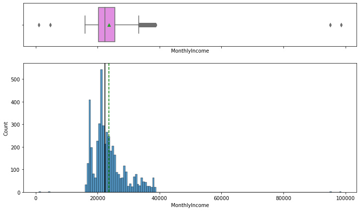

```python
histogram_boxplot(data, 'MonthlyIncome')
```

MonthlyIncome is slightly right skewed, It also has many outliers. There are 233 null values. Most of the outliers are upper outliers, there are a few lower ouliers too. Since this data is skewed and has outliers, we can use the median of the column to populate the missing values. Also we should consider outlier treatment for this column. To prevent data leakeage, the nulls will be imputed after the data is split for training and testing data. Then the nulls in the train and test data will be populated with the median of the training data.

#### Missing value - Age

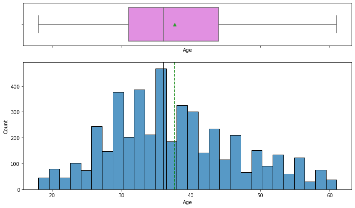

```python
histogram_boxplot(data, 'Age')
```

Age is slightly right skewed. There are 226 nulls. There are no outliers for this column. Due to its skewness, it would be best to populate it with the median instead of the mean. To prevent data leakeage, the nulls will be imputed after the data is split for training and testing data. Then the nulls in the train and test data will be populated with the median of the training data.

#### Missing value - NumberOfTrips

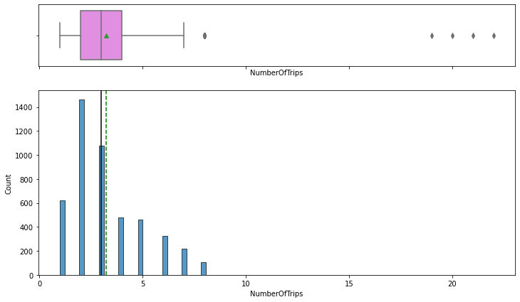

```python
histogram_boxplot(data, 'NumberOfTrips')
```

NumberOfTrips is very slightly right skewed. There are 140 null values. Also there are some upper outliers too for this column. Since the data is slightly skewed, it would be best to populate it with the median instead of the mean. Also, this will be a good column for outlier treatment. To prevent data leakeage, the nulls will be imputed after the data is split for training and testing data. Then the nulls in the train and test data will be populated with the median of the training data.

#### Missing value - NumberOfChildrenVisiting

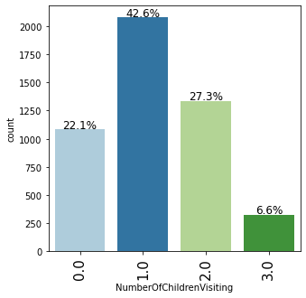

```python
#NumberOfChildrenVisiting is not numeric so we can use the barplot here
labeled_barplot(data, 'NumberOfChildrenVisiting', perc=True)
```

NumberOfChildrenVisiting is categorical in nature. There are 66 null values. Since there are only 66 null values we can drop the null values.

```python
#Dropping the rows where NumberOfChildrenVisiting is null
data = data.drop(data.index[data['NumberOfChildrenVisiting'].isnull()])
```

#### Missing value - NumberOfFollowups

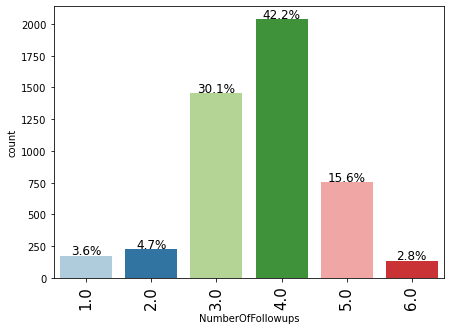

```python
#NumberOfFollowups is not numeric so we can use the barplot here
labeled_barplot(data, 'NumberOfFollowups', perc=True)
```

There are 45 null values. Since there are only 45 nulls we can drop these rows.

```python
#Dropping the rows where NumberOfFollowups is null
data = data.drop(data.index[data['NumberOfFollowups'].isnull()])
```

#### Missing value - PreferredPropertyStar

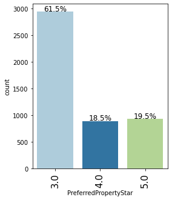

```python
#PreferredPropertyStar is not numeric so we can use the barplot here
labeled_barplot(data, 'PreferredPropertyStar', perc=True)
```

PreferredPropertyStar looks like a categorical column. There are 26 null values. Since There are only 26 null values we can drop the null values

```python
#Dropping the rows where PreferredPropertyStar is null
data = data.drop(data.index[data['PreferredPropertyStar'].isnull()])
```

#### Missing value - TypeofContact

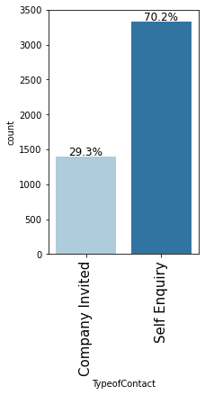

```python
#TypeofContact is not numeric so we can use the barplot here
labeled_barplot(data, 'TypeofContact', perc=True)
```

TypeofContact has 2 categories. It has 25 null values. Since the data only has 25 null values, we can drop the nulls.

```python
#Dropping the rows where TypeOfContact is null
data = data.drop(data.index[data['TypeofContact'].isnull()])
```

```python
#Check to ensure there are no more nulls
data.isnull().sum().sort_values(ascending=False)
```

```
DurationOfPitch             226
Age                         226
MonthlyIncome               208
NumberOfTrips               140
MaritalStatus                 0
Designation                   0
NumberOfChildrenVisiting      0
OwnCar                        0
PitchSatisfactionScore        0
Passport                      0
ProdTaken                     0
PreferredPropertyStar         0
NumberOfFollowups             0
NumberOfPersonVisiting        0
Gender                        0
Occupation                    0
CityTier                      0
TypeofContact                 0
ProductPitched                0
dtype: int64
```

Besides, DurationOfPitch, Age, MonthlyIncome and NumberOfTrips there are no null values. The null values for the 4 columns will be imputed after the data is split into train and test data.

### Outlier Treatment

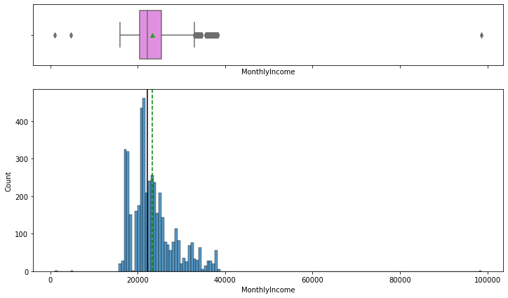

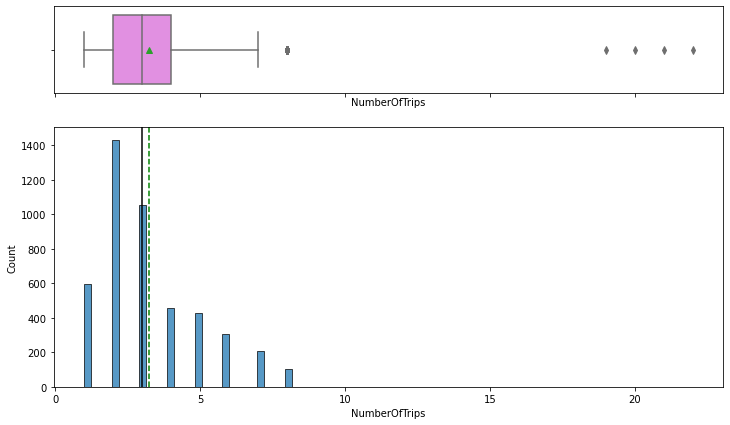

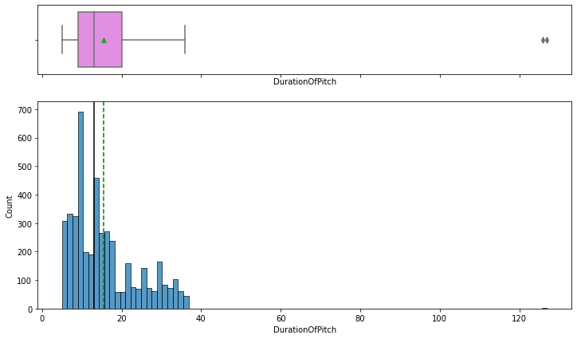

```python
#Outliers detection using box plot
#Listing the columns with continous numeric data and outliers
numerical_col = data[["MonthlyIncome", "NumberOfTrips","DurationOfPitch"]]
for colname in numerical_col:
      histogram_boxplot(data, colname)
```

Monthly Income has upper and lower outliers. NumberOfTrips and DurationOfPitch has only upper outliers

```python
# functions to treat outliers by flooring and capping
def treat_outliers(df, col):
    """
    Treats outliers in a variable

    df: dataframe
    col: dataframe column
    """
    Q1 = df[col].quantile(0.25)  # 25th quantile
    Q3 = df[col].quantile(0.75)  # 75th quantile
    IQR = Q3 - Q1
    Lower_Whisker = Q1 - 1.5 * IQR
    Upper_Whisker = Q3 + 1.5 * IQR

    # all the values smaller than Lower_Whisker will be assigned the value of Lower_Whisker
    # all the values greater than Upper_Whisker will be assigned the value of Upper_Whisker
    df[col] = np.clip(df[col], Lower_Whisker, Upper_Whisker)

    return df
def treat_outliers_all(df, col_list):
    """
    Treat outliers in a list of variables

    df: dataframe
    col_list: list of dataframe columns
    """
    for c in col_list:
        df = treat_outliers(df, c)

    return df
```

```python
data = treat_outliers_all(data, numerical_col)
```

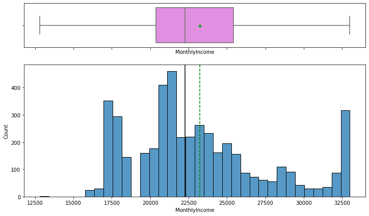

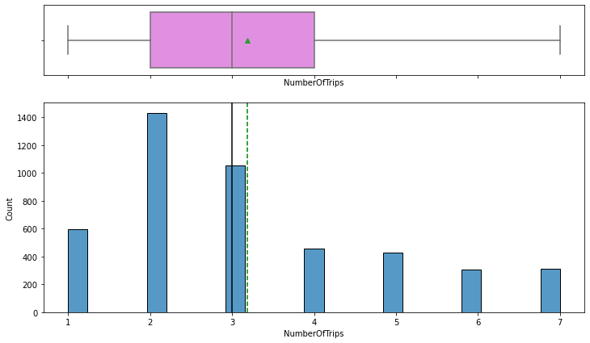

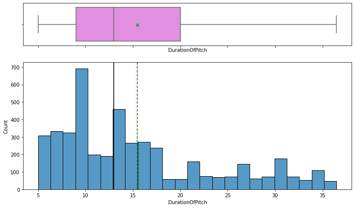

```python
# let's look at box plot to see if outliers have been treated or not
for colname in numerical_col:
      histogram_boxplot(data, colname)
```

The outliers have been treated.